# News Audience Analytics Dashboard: Content Performance & Reader Engagement

An editorial intelligence report built on the MIND News Dataset

Lindsey Hornberger

2026-01-12

# News Audience Analytics

## Overview

Audience engagement summary — MIND News Dataset

| Metric | Value |
| --- | --- |
| Total Sessions | 156,964 |
| Unique Users | 50,000 |
| Overall CTR | 4.04% |
| Avg Articles Shown per Session | 37.2 |
| Avg Clicks per Session | 1.51 |

### About this report

This report analyzes reader engagement patterns from the **Microsoft News Dataset (MIND-small)**, a benchmark dataset drawn from anonymized behavior logs of Microsoft News users collected between **October 12 and November 22, 2019**. The dataset contains a random sample of **50,000 users**, their click histories, and impression logs across 51,002 unique articles.

> **Note on weekday coverage:** Friday does not appear in this dataset’s collection window. All weekday analyses reflect Monday–Thursday and Saturday–Sunday patterns only.

The analysis is structured to answer the questions a newsroom audience analyst asks daily:

- **Who is engaging** — how readers segment by engagement depth
- **When they engage** — hourly and weekday patterns that inform publish timing
- **What they click** — which content categories and headline structures drive the highest CTR
- **What it means** — plain-language editorial recommendations drawn from the data

[figure not shown]

## Audience Behavior

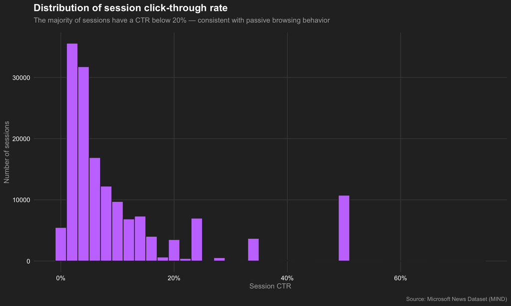

[figure not shown]

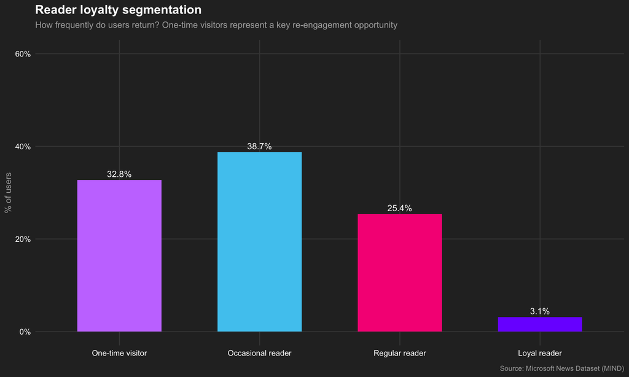

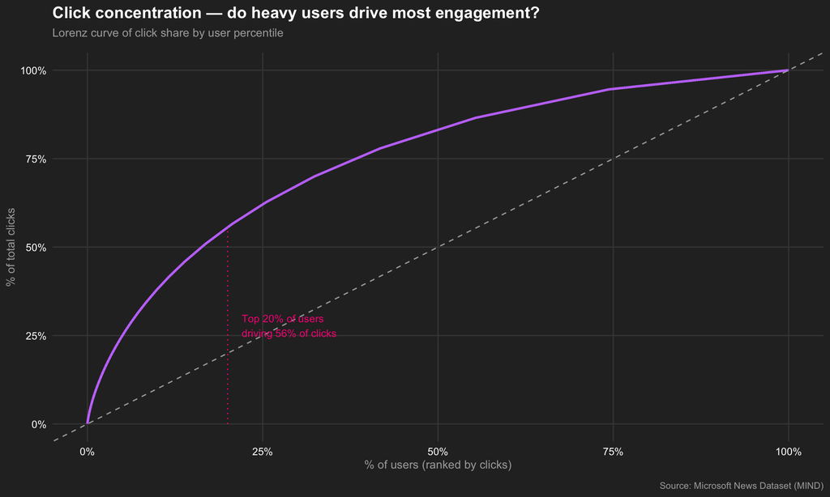

## Timing & Patterns

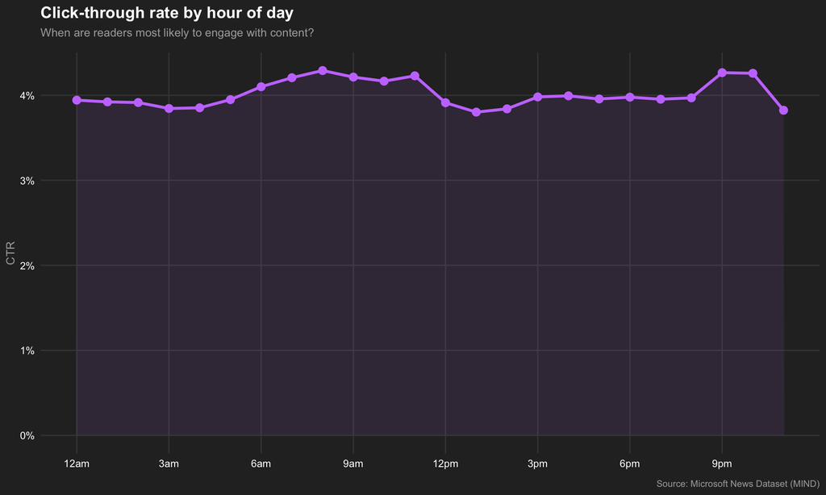

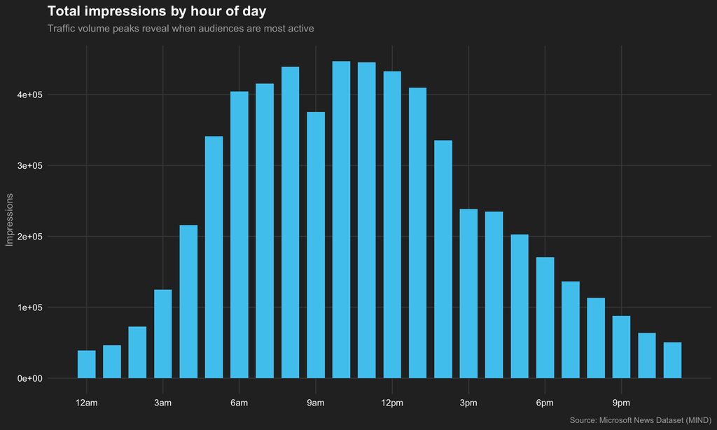

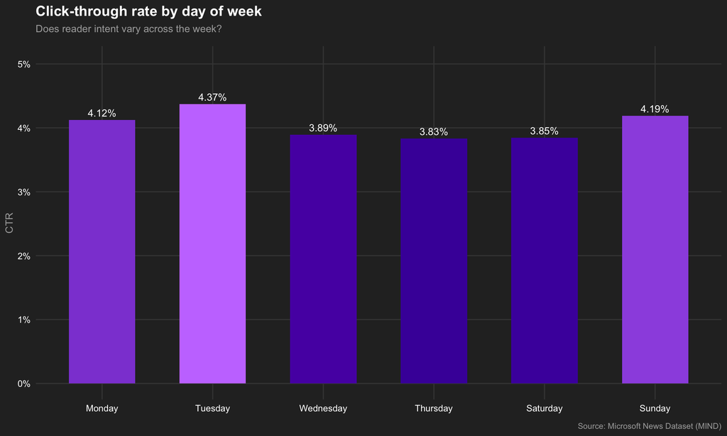

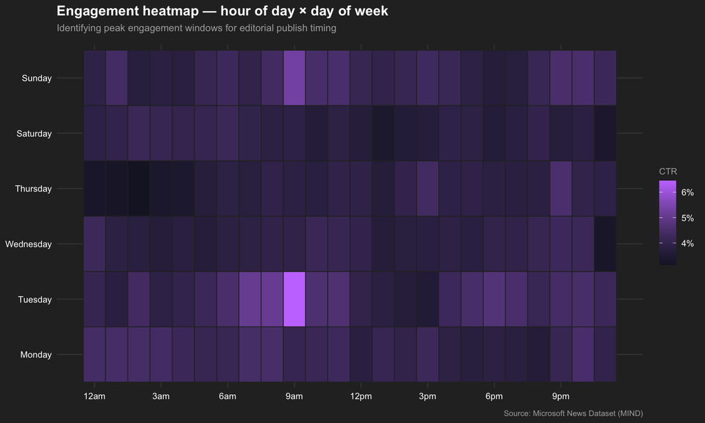

## Content Performance

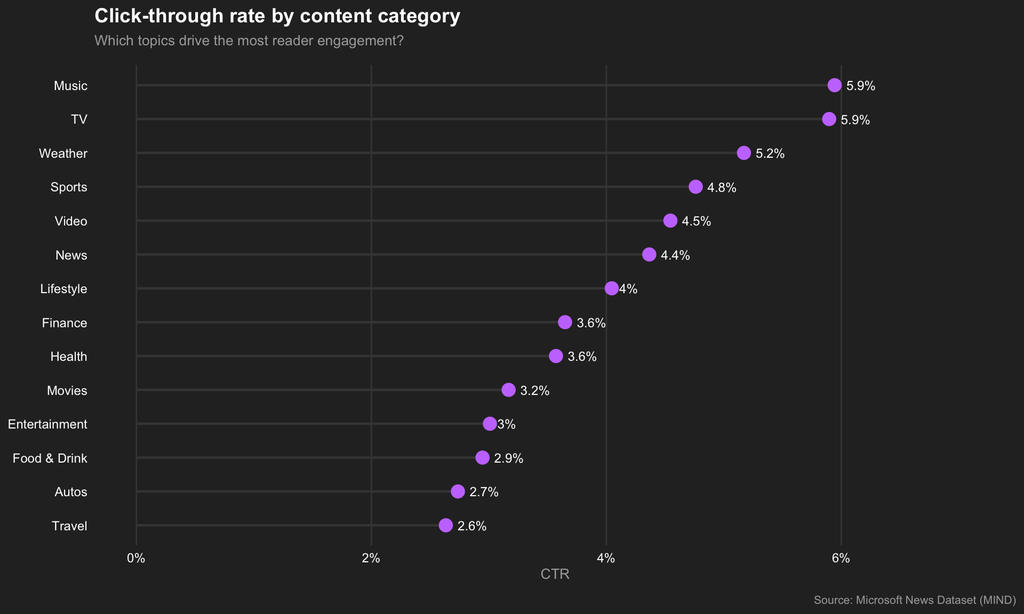

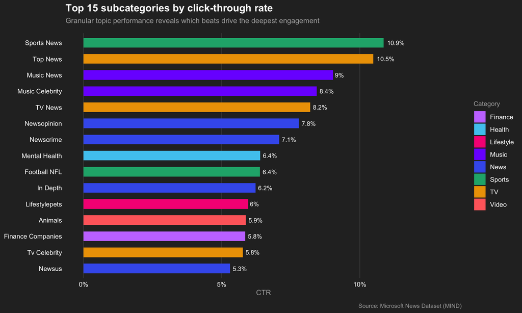

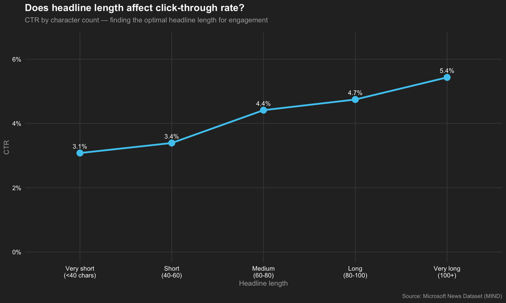

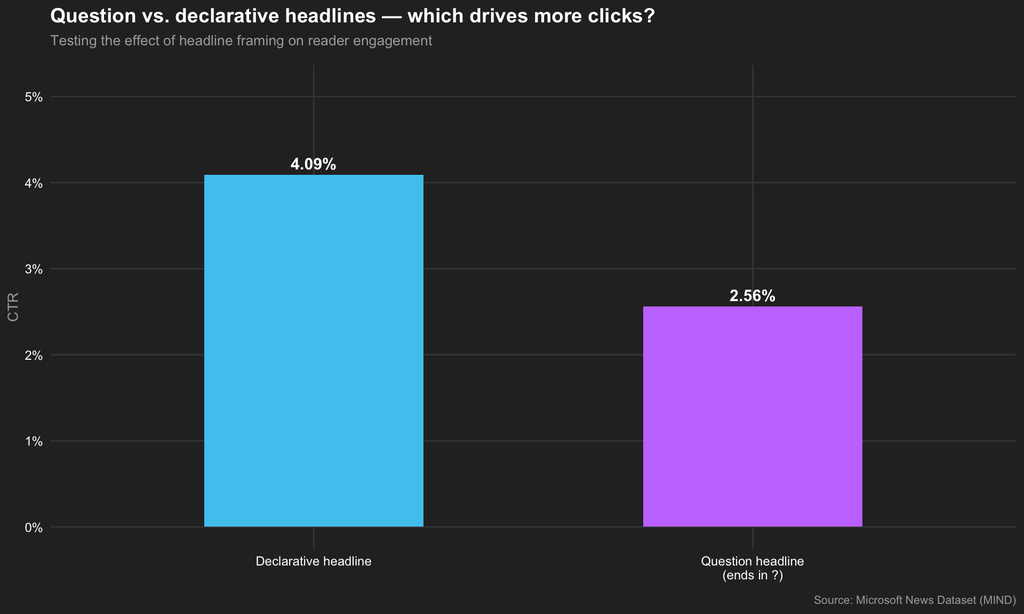

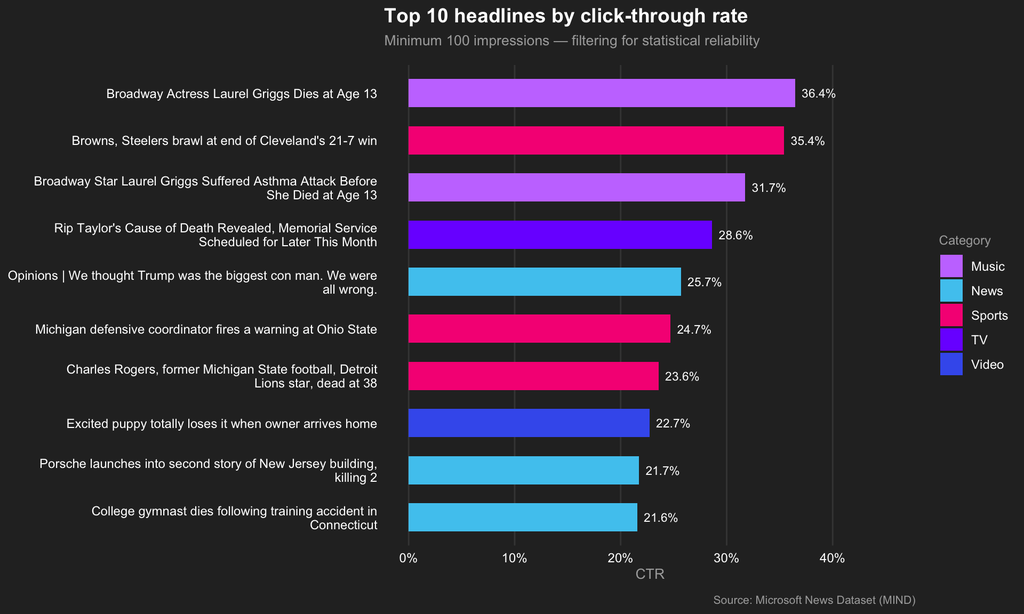

## Editorial Insights

### 1. Publish high-performing content during peak engagement windows

Reader intent peaks at **8:00** — CTR during this hour is **4.29%**, compared to a daily average of **4.02%**. **Tuesday** is the strongest day of the week for engagement.

> **Recommendation:** Schedule high-priority content — particularly from top-performing categories — to publish during morning peak windows. Breaking news aside, evergreen and feature content should be timed to align with demonstrated audience attention patterns.

### 2. Music drives the strongest engagement — lean into it

**Music** has the highest CTR in the dataset at **5.94%**, meaningfully outperforming **Travel** at the bottom (**2.63%**).

> **Recommendation:** Audience interest is not evenly distributed across coverage areas. Editors should factor category-level engagement benchmarks into coverage planning — not to chase clicks, but to ensure high-investment content is reaching receptive audiences and to identify undercovered topics with demonstrated reader appetite.

### 3. Question headlines underperform declarative headlines by 37.4%

Headlines framed as questions achieve a CTR of **2.56%** versus **4.09%** for declarative headlines — a 37.4% drop.

> **Recommendation:** Declarative headlines outperform question framing in this feed environment, suggesting readers respond more strongly to authoritative statements than open-ended prompts. Editors should favor clear, direct headline construction over question framing.

### About this analysis

This report was built using the **Microsoft News Dataset (MIND)**, a large-scale benchmark dataset of anonymized impression logs from Microsoft News. The dataset contains **156,964 sessions**, **50,000 unique users**, and **51,002 articles** across multiple content categories.

Analytical methods include session-level engagement segmentation, CTR analysis by content category and headline structure, temporal engagement modeling, and user loyalty classification. All visualizations built in R using ggplot2.

*Data source: Microsoft News Dataset (MIND) — https://msnews.github.io/*